# Business Statistics

Mahima Tendulkar

```r
# R Packages for Question1 and Question2
library(tidyverse)
library(dplyr)
options(width = 600)
library(data.table) # for as.data.table()
library(emmeans) # for emmeans() and pairs()
library(gridExtra) # for grid.arrange()
library(knitr) # for kable()
library(kableExtra) # for cell_spec()
library(ggplot2)
library(Hmisc) # for correlation functions
```

# Book Sales

## Section 1

The following section of the report fulfills the requests of the managers of a publishing company.

The requests are summarized below:

1. Find whether books from different genres have different daily sales on average.
2. Do books have more/fewer sales depending on their average review scores and the total number of reviews?
3. Find the effect of sale price upon the number of sales, and is this different across genres

The data dictionary of the dataset used is explained in the section below:

### Data Dictionary

| Variable | Description |
| --- | --- |
| sold by | Name of the service that sold the particular e-book |
| publisher.type | Publisher type: amazon, big five, indie, single author, small/medium |
| genre | The category or style of a book |
| avg.review | Average of the reviews across all days in the given time span. |
| daily.sales | Average number of sales (minus refunds) across all days in the given time period |
| total.reviews | Total number of reviews across all days in the given time span. |
| sale.price | Average price for which the book sold across all days in the given time period. |

### Data Read and Preparation

```r
#Read the dataset publisher_sales.csv
data.books <- read_csv("publisher_sales.csv")

#Check Structure
#str(data.books)

#Convert columns as factors
columns.books <- c("publisher.type","genre")
data.books[columns.books] <- lapply(data.books[columns.books],as.factor)

#Check structure
#str(data.books)

#Check summary
summary(data.books[c("publisher.type","genre","avg.review","daily.sales","total.reviews","sale.price")])
```

```
##        publisher.type         genre        avg.review     daily.sales     total.reviews     sale.price
##  amazon       :  78   childrens  :2000   Min.   :0.000   Min.   : -0.53   Min.   :  0.0   Min.   : 0.740
##  big five     :1658   fiction    :2000   1st Qu.:4.100   1st Qu.: 56.77   1st Qu.:105.0   1st Qu.: 7.140
##  indie        :1330   non_fiction:2000   Median :4.400   Median : 74.29   Median :128.0   Median : 8.630
##  single author: 809                      Mean   :4.267   Mean   : 79.11   Mean   :132.6   Mean   : 8.641
##  small/medium :2125                      3rd Qu.:4.620   3rd Qu.: 98.02   3rd Qu.:163.0   3rd Qu.:10.160
##                                          Max.   :4.980   Max.   :207.98   Max.   :248.0   Max.   :17.460
```

### Data Understanding

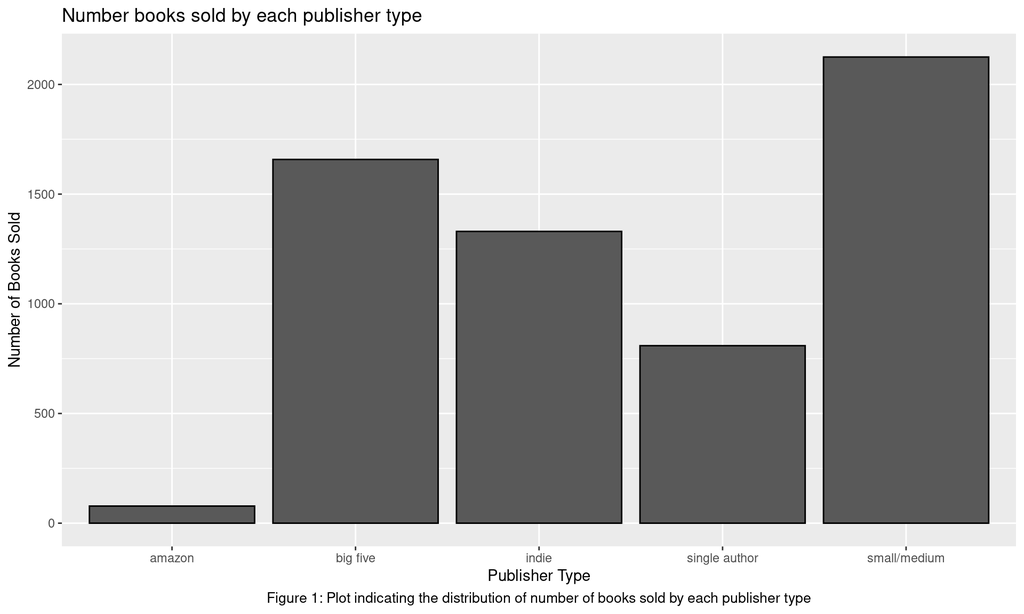

```r
#Plot indicating the distribution of each publisher type
ggplot(data.books, aes(x=publisher.type)) + geom_bar(colour='black') + labs(x="Publisher Type" , y="Number of Books Sold" ,title = "Number books sold by each publisher type", caption = "Figure 1: Plot indicating the distribution of number of books sold by each publisher type") +
  theme(plot.caption = element_text(size=10,hjust=0.5))
```

### Regression Models

```r
#Request Do books from different genres have different daily sales on average?

#Table for summarizing the Average daily sales for each genre of book
book.table <- data.books %>% group_by(genre) %>%
  summarise(No_of_Books= n(), Average_daily_sales = mean(daily.sales))

#Print the book.table
print(as.data.table(book.table))
```

```
##          genre No_of_Books Average_daily_sales
## 1:   childrens        2000            55.57726
## 2:     fiction        2000           105.88591
## 3: non_fiction        2000            75.86584
```

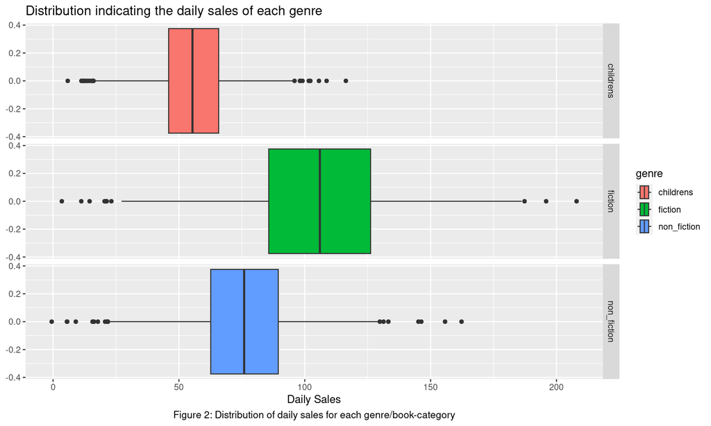

```r
#Box plot for better understanding the daily sales distribution for each genre
ggplot(data.books, aes(x=daily.sales, fill=genre)) + facet_grid(genre~.) + geom_boxplot() +labs(title = "Distribution indicating the daily sales of each genre",x="Daily Sales", caption= "Figure 2: Distribution of daily sales for each genre/book-category") +
  theme(plot.caption = element_text(size=10,hjust=0.5))
```

```r
#perform two-way ANOVA
m.daily.sales.by.genre <- lm(daily.sales ~ genre  , data=data.books)
summary(m.daily.sales.by.genre)
```

```
##
## Call:
## lm(formula = daily.sales ~ genre, data = data.books)
##
## Residuals:
##      Min       1Q   Median       3Q      Max
## -102.396  -13.326   -0.076   13.249  102.094
##
## Coefficients:
##                  Estimate Std. Error t value Pr(>|t|)
## (Intercept)       55.5773     0.4973  111.76   <2e-16 ***
## genrefiction      50.3087     0.7033   71.53   <2e-16 ***
## genrenon_fiction  20.2886     0.7033   28.85   <2e-16 ***
## ---
## Signif. codes:  0 '***' 0.001 '**' 0.01 '*' 0.05 '.' 0.1 ' ' 1
##
## Residual standard error: 22.24 on 5997 degrees of freedom
## Multiple R-squared:  0.4635, Adjusted R-squared:  0.4633
## F-statistic:  2590 on 2 and 5997 DF,  p-value: < 2.2e-16
```

```r
head(cbind(as.data.frame(book.table[c("genre","Average_daily_sales")]), model.matrix(m.daily.sales.by.genre)))
```

```
##         genre Average_daily_sales (Intercept) genrefiction genrenon_fiction
## 1   childrens            55.57726           1            0                0
## 2     fiction           105.88591           1            0                1
## 3 non_fiction            75.86584           1            0                1
## 4   childrens            55.57726           1            1                0
## 5     fiction           105.88591           1            0                0
## 6 non_fiction            75.86584           1            0                0
```

```r
(m.daily.sales.by.genre.emm <- emmeans(m.daily.sales.by.genre, ~genre))
```

```
##  genre       emmean    SE   df lower.CL upper.CL
##  childrens     55.6 0.497 5997     54.6     56.6
##  fiction      105.9 0.497 5997    104.9    106.9
##  non_fiction   75.9 0.497 5997     74.9     76.8
##
## Confidence level used: 0.95
```

```r
(m.daily.sales.by.genre.pairs <- pairs(m.daily.sales.by.genre.emm)  )
```

```
##  contrast                estimate    SE   df t.ratio p.value
##  childrens - fiction        -50.3 0.703 5997 -71.534  <.0001
##  childrens - non_fiction    -20.3 0.703 5997 -28.849  <.0001
##  fiction - non_fiction       30.0 0.703 5997  42.686  <.0001
##
## P value adjustment: tukey method for comparing a family of 3 estimates
```

```r
(m.daily.sales.by.genre.pairs <- confint(pairs(m.daily.sales.by.genre.emm)))
```

```
##  contrast                estimate    SE   df lower.CL upper.CL
##  childrens - fiction        -50.3 0.703 5997    -52.0    -48.7
##  childrens - non_fiction    -20.3 0.703 5997    -21.9    -18.6
##  fiction - non_fiction       30.0 0.703 5997     28.4     31.7
##
## Confidence level used: 0.95
## Conf-level adjustment: tukey method for comparing a family of 3 estimates
```

```r
#Request 2: Do books have more/fewer sales depending upon their average review scores and total number of reviews?

#filter reviews '0'
data.books.filtered <- data.books %>% filter(total.reviews != 0)

#Correlation matrix for selected columns
rcorr(as.matrix(select(data.books.filtered, daily.sales, avg.review , total.reviews)))
```

```
##               daily.sales avg.review total.reviews
## daily.sales          1.00          0          0.68
## avg.review           0.00          1          0.00
## total.reviews        0.68          0          1.00
##
## n= 5977
##
##
## P
##               daily.sales avg.review total.reviews
## daily.sales               0.8344     0.0000
## avg.review    0.8344                 0.7945
## total.reviews 0.0000      0.7945
```

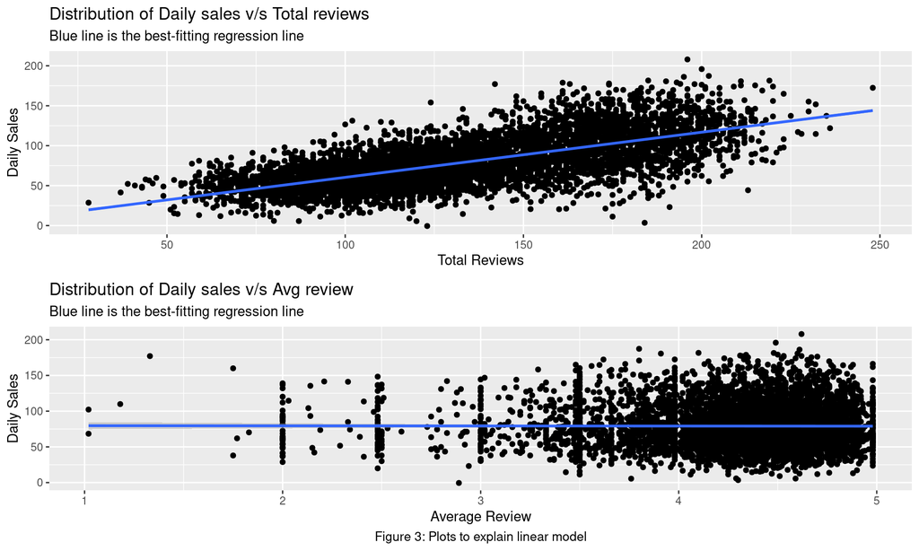

```r
#To better understand the correlation between the variables.
grid.arrange(
ggplot(data.books.filtered, aes(y=daily.sales, x=total.reviews)) + geom_point() + labs(x="Total Reviews", y="Daily Sales", title="Distribution of Daily sales v/s Total reviews", subtitle= "Blue line is the best-fitting regression line") + geom_smooth(method=lm),

ggplot(data.books.filtered, aes(y=daily.sales, x=avg.review)) + geom_point() + labs(x="Average Review", y="Daily Sales", title="Distribution of Daily sales v/s Avg review", subtitle= "Blue line is the best-fitting regression line" , caption = "Figure 3: Plots to explain linear model") +
  theme(plot.caption = element_text(size=10,hjust=0.5)) + geom_smooth(method=lm)
)
```

```r
#Linear Regression model
m.sales.by.avgreview.totalreviews <- lm(daily.sales~avg.review + total.reviews, data=data.books.filtered)
summary(m.sales.by.avgreview.totalreviews)
```

```
##
## Call:
## lm(formula = daily.sales ~ avg.review + total.reviews, data = data.books.filtered)
##
## Residuals:
##      Min       1Q   Median       3Q      Max
## -104.334  -14.632   -0.742   13.839   93.473
##
## Coefficients:
##                Estimate Std. Error t value Pr(>|t|)
## (Intercept)    5.163958   2.651313   1.948   0.0515 .
## avg.review    -0.299177   0.565828  -0.529   0.5970
## total.reviews  0.564926   0.007838  72.077   <2e-16 ***
## ---
## Signif. codes:  0 '***' 0.001 '**' 0.01 '*' 0.05 '.' 0.1 ' ' 1
##
## Residual standard error: 22.22 on 5974 degrees of freedom
## Multiple R-squared:  0.4651, Adjusted R-squared:  0.465
## F-statistic:  2598 on 2 and 5974 DF,  p-value: < 2.2e-16
```

```r
# To study the Interaction between avg.review and total.reviews
m.sales.by.avgreview.totalreviews.interaction <- lm(daily.sales~avg.review * total.reviews, data=data.books.filtered)
summary(m.sales.by.avgreview.totalreviews.interaction)
```

```
##
## Call:
## lm(formula = daily.sales ~ avg.review * total.reviews, data = data.books.filtered)
##
## Residuals:
##      Min       1Q   Median       3Q      Max
## -104.327  -14.583   -0.773   13.859   93.915
##
## Coefficients:
##                          Estimate Std. Error t value Pr(>|t|)
## (Intercept)              -7.36525    9.34333  -0.788    0.431
## avg.review                2.61997    2.16273   1.211    0.226
## total.reviews             0.65854    0.06740   9.770   <2e-16 ***
## avg.review:total.reviews -0.02181    0.01560  -1.398    0.162
## ---
## Signif. codes:  0 '***' 0.001 '**' 0.01 '*' 0.05 '.' 0.1 ' ' 1
##
## Residual standard error: 22.21 on 5973 degrees of freedom
## Multiple R-squared:  0.4653, Adjusted R-squared:  0.465
## F-statistic:  1733 on 3 and 5973 DF,  p-value: < 2.2e-16
```

```r
#ANOVA to compare 2 models
anova(m.sales.by.avgreview.totalreviews, m.sales.by.avgreview.totalreviews.interaction)
```

```
## Analysis of Variance Table
##
## Model 1: daily.sales ~ avg.review + total.reviews
## Model 2: daily.sales ~ avg.review * total.reviews
##   Res.Df     RSS Df Sum of Sq      F Pr(>F)
## 1   5974 2948425
## 2   5973 2947460  1    965.05 1.9557  0.162
```

```r
#Using Estimation approach
cbind(coefficient= coef(m.sales.by.avgreview.totalreviews),confint(m.sales.by.avgreview.totalreviews))
```

```
##               coefficient       2.5 %     97.5 %
## (Intercept)     5.1639576 -0.03357359 10.3614887
## avg.review     -0.2991774 -1.40840374  0.8100490
## total.reviews   0.5649258  0.54956090  0.5802907
```

```r
# Request 3: What is the effect of sale price upon the number of sales, and is this different across genres?

#Summarise
book.table.genre <- data.books %>% group_by(genre) %>%
  summarise(No_of_Books_sold= n(), Average_Sale_Price = mean(sale.price))

#print book.table.genre
print(as.data.table(book.table.genre))
```

```
##          genre No_of_Books_sold Average_Sale_Price
## 1:   childrens             2000            9.98973
## 2:     fiction             2000            8.02283
## 3: non_fiction             2000            7.91166
```

```r
# Linear model
m.sales.by.price.genre <- lm(daily.sales~sale.price+genre, data=data.books)
summary(m.sales.by.price.genre)
```

```
##
## Call:
## lm(formula = daily.sales ~ sale.price + genre, data = data.books)
##
## Residuals:
##      Min       1Q   Median       3Q      Max
## -102.357  -13.311    0.031   13.097  102.924
##
## Coefficients:
##                  Estimate Std. Error t value Pr(>|t|)
## (Intercept)       63.8931     1.5195   42.05  < 2e-16 ***
## sale.price        -0.8324     0.1438   -5.79  7.4e-09 ***
## genrefiction      48.6713     0.7562   64.36  < 2e-16 ***
## genrenon_fiction  18.5587     0.7624   24.34  < 2e-16 ***
## ---
## Signif. codes:  0 '***' 0.001 '**' 0.01 '*' 0.05 '.' 0.1 ' ' 1
##
## Residual standard error: 22.18 on 5996 degrees of freedom
## Multiple R-squared:  0.4665, Adjusted R-squared:  0.4662
## F-statistic:  1748 on 3 and 5996 DF,  p-value: < 2.2e-16
```

```r
# Interaction
m.sales.by.price.genre.interaction <- lm(daily.sales~sale.price*genre, data=data.books)
summary(m.sales.by.price.genre.interaction)
```

```
##
## Call:
## lm(formula = daily.sales ~ sale.price * genre, data = data.books)
##
## Residuals:
##     Min      1Q  Median      3Q     Max
## -102.38  -13.37    0.03   13.08  102.37
##
## Coefficients:
##                             Estimate Std. Error t value Pr(>|t|)
## (Intercept)                  72.8781     2.5025  29.122  < 2e-16 ***
## sale.price                   -1.7319     0.2456  -7.053 1.95e-12 ***
## genrefiction                 35.1993     3.2740  10.751  < 2e-16 ***
## genrenon_fiction              6.5492     3.2040   2.044 0.040989 *
## sale.price:genrefiction       1.4587     0.3546   4.114 3.94e-05 ***
## sale.price:genrenon_fiction   1.2817     0.3469   3.695 0.000222 ***
## ---
## Signif. codes:  0 '***' 0.001 '**' 0.01 '*' 0.05 '.' 0.1 ' ' 1
##
## Residual standard error: 22.15 on 5994 degrees of freedom
## Multiple R-squared:  0.4683, Adjusted R-squared:  0.4679
## F-statistic:  1056 on 5 and 5994 DF,  p-value: < 2.2e-16
```

```r
# Model comparison using anova
anova(m.sales.by.price.genre,m.sales.by.price.genre.interaction)
```

```
## Analysis of Variance Table
##
## Model 1: daily.sales ~ sale.price + genre
## Model 2: daily.sales ~ sale.price * genre
##   Res.Df     RSS Df Sum of Sq      F   Pr(>F)
## 1   5996 2949642
## 2   5994 2939524  2     10118 10.316 3.37e-05 ***
## ---
## Signif. codes:  0 '***' 0.001 '**' 0.01 '*' 0.05 '.' 0.1 ' ' 1
```

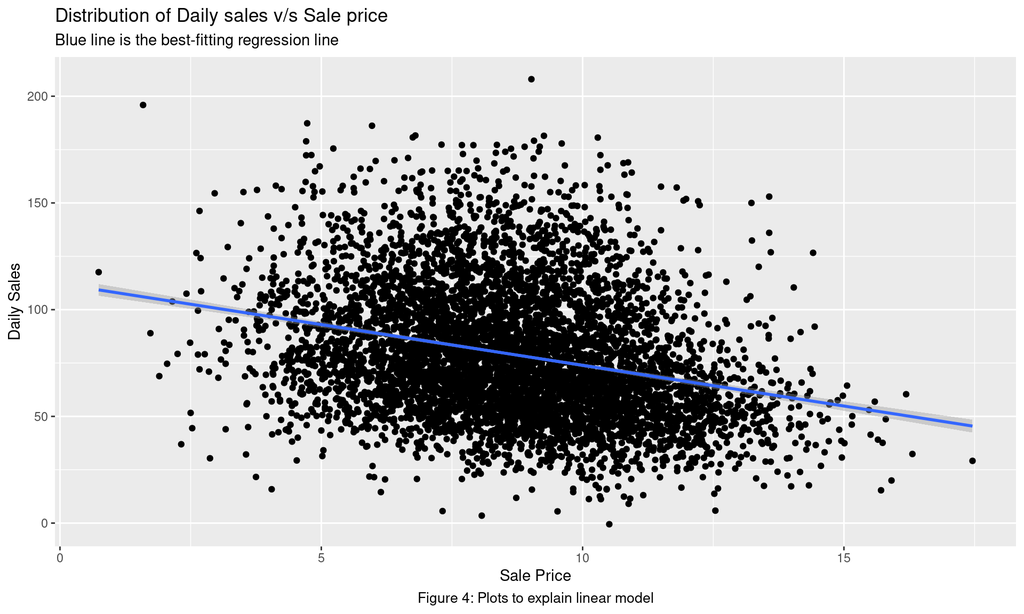

```r
# Plot for visualisation of linear relationship
ggplot(data.books, aes(y=daily.sales, x=sale.price)) + geom_point() + labs(x="Sale Price", y="Daily Sales", title="Distribution of Daily sales v/s Sale price", subtitle= "Blue line is the best-fitting regression line", caption = "Figure 4: Plots to explain linear model") +
  theme(plot.caption = element_text(size=10,hjust=0.5)) + geom_smooth(method=lm)
```

## Section 2

#### Introduction and brief data analysis

This section presents the outcome of an extensive analysis performed on the Publisher Sales data. The data used for analysis provides information about e-book sales by 13 different publishers over many months. It consists of 6000 unique observations, each representing a book’s sales, reviews, and publisher details. As observed from the summary given below, we can make the following notes about the data:

1. There are five different publisher types: amazon, big five, indie, single author, and small/medium.
2. Observations are categorized into three different genres: children’s, fiction, and non-fiction.
3. Average Review is on a scale of (0-5) with 0 being the lowest and five being the highest.
4. Daily sales have a negative minimum value (since there might be refunds made in the given time period while the purchase was made in the previous period)
5. Some books have ‘0’ total reviews, which means that they are not rated yet.

```
##        publisher.type         genre        avg.review     daily.sales     total.reviews     sale.price
##  amazon       :  78   childrens  :2000   Min.   :0.000   Min.   : -0.53   Min.   :  0.0   Min.   : 0.740
##  big five     :1658   fiction    :2000   1st Qu.:4.100   1st Qu.: 56.77   1st Qu.:105.0   1st Qu.: 7.140
##  indie        :1330   non_fiction:2000   Median :4.400   Median : 74.29   Median :128.0   Median : 8.630
##  single author: 809                      Mean   :4.267   Mean   : 79.11   Mean   :132.6   Mean   : 8.641
##  small/medium :2125                      3rd Qu.:4.620   3rd Qu.: 98.02   3rd Qu.:163.0   3rd Qu.:10.160
##                                          Max.   :4.980   Max.   :207.98   Max.   :248.0   Max.   :17.460
```

To get a clear understanding of the data, a graph was made. Below is the plot representing the distribution of each publisher type (Figure 1). It can be inferred that the maximum number of e-books were sold by small/medium publisher types, while amazon sold the least number of e-books.

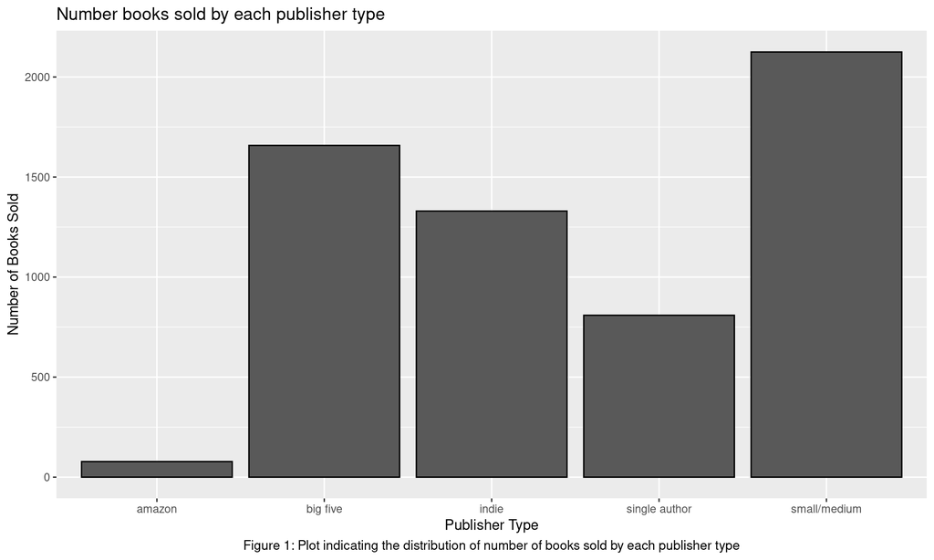

### Request 1: Do books from different genres have different daily sales on average?

To Find whether books from different genres have different daily sales on average, the mean daily sales was calculated for each genre. The below table represents the Genre, No_of_Books in each category, and their Average_daily_sales. It can be observed that the fiction genre was the most popular choice among the readers, while non-fiction was secondary, followed by children’s.

```
##          genre No_of_Books Average_daily_sales
## 1:   childrens        2000            55.57726
## 2:     fiction        2000           105.88591
## 3: non_fiction        2000            75.86584
```

The daily sales distribution can be better understood with the below box plot.

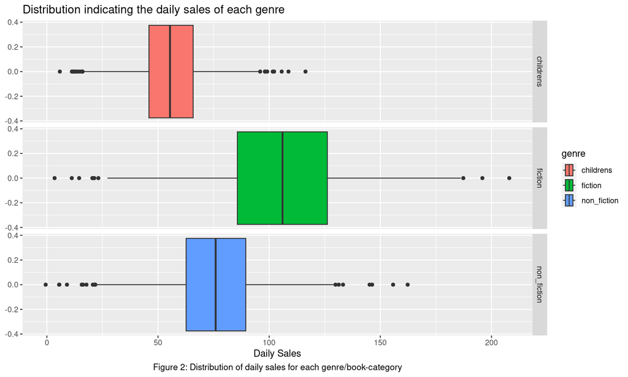

```
##
## Call:
## lm(formula = daily.sales ~ genre, data = data.books)
##
## Residuals:
##      Min       1Q   Median       3Q      Max
## -102.396  -13.326   -0.076   13.249  102.094
##
## Coefficients:
##                  Estimate Std. Error t value Pr(>|t|)
## (Intercept)       55.5773     0.4973  111.76   <2e-16 ***
## genrefiction      50.3087     0.7033   71.53   <2e-16 ***
## genrenon_fiction  20.2886     0.7033   28.85   <2e-16 ***
## ---
## Signif. codes:  0 '***' 0.001 '**' 0.01 '*' 0.05 '.' 0.1 ' ' 1
##
## Residual standard error: 22.24 on 5997 degrees of freedom
## Multiple R-squared:  0.4635, Adjusted R-squared:  0.4633
## F-statistic:  2590 on 2 and 5997 DF,  p-value: < 2.2e-16
```

From this summary of the model, we can infer that there is a statistically significant difference between the daily sales of 3 categories/genres. The difference between sales of the children’s category and the non-fiction category is 20.28, and the difference between the sales of the fiction category and the children’s category is 50.30.

### Request 2: Do books have more/fewer sales depending upon their average review scores and total number of reviews?

In this section, statistical analysis has been carried out to find whether books have more/fewer sales depending on their average review scores and the total number of reviews.

To better understand the effect of book reviews on sales, the books that are not rated, i.e., books with “0” total reviews, are filtered out.

Below is the summary of the linear model to understand the impact of average and total reviews on daily sales:

```
##
## Call:
## lm(formula = daily.sales ~ avg.review + total.reviews, data = data.books.filtered)
##
## Residuals:
##      Min       1Q   Median       3Q      Max
## -104.334  -14.632   -0.742   13.839   93.473
##
## Coefficients:
##                Estimate Std. Error t value Pr(>|t|)
## (Intercept)    5.163958   2.651313   1.948   0.0515 .
## avg.review    -0.299177   0.565828  -0.529   0.5970
## total.reviews  0.564926   0.007838  72.077   <2e-16 ***
## ---
## Signif. codes:  0 '***' 0.001 '**' 0.01 '*' 0.05 '.' 0.1 ' ' 1
##
## Residual standard error: 22.22 on 5974 degrees of freedom
## Multiple R-squared:  0.4651, Adjusted R-squared:  0.465
## F-statistic:  2598 on 2 and 5974 DF,  p-value: < 2.2e-16
```

From the above summary, it can be inferred that the impact of the average review on the daily sale is statistically insignificant. But the total number of reviews’ effect on daily sales is highly significant. Keeping average review constant, for every increase in total reviews, it causes 0.56 increase in the daily sales.

To better understand the difference, the visualization representing the same results is shown in (Figure 3). The distribution of daily sales v/s total reviews plot has a best-fitted line showing a positive slope, which means there is a positive correlation between the two. While in the second plot, we can see that daily sales and avg reviews do not have any positive or negative correlation.

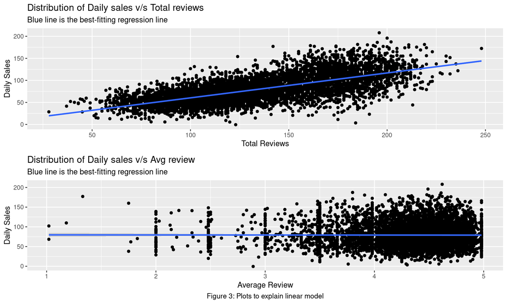

In order to understand the combined effect of both the variables (average review and total reviews) on the outcome variable (daily sales), another linear model with the interaction term was used. But when the model was compared with the above-mentioned model, there was no significant difference in daily sales considering the combined effect of both the total reviews and avg reviews.

### Request 3: What is the effect of sale price upon the number of sales, and is this different across genres?

In this section, the analysis was carried out to study the effect of the sales price on the number of sales and to find whether it is different for different genres.

```
##          genre No_of_Books_sold Average_Sale_Price Average_daily_sale
## 1:   childrens             2000            9.98973           55.57726
## 2:     fiction             2000            8.02283          105.88591
## 3: non_fiction             2000            7.91166           75.86584
```

To further understand the effect of the sale price and genre on daily sales, a linear model was implemented, and the outcome/summary of the model is as follows:

```
##
## Call:
## lm(formula = daily.sales ~ sale.price + genre, data = data.books)
##
## Residuals:
##      Min       1Q   Median       3Q      Max
## -102.357  -13.311    0.031   13.097  102.924
##
## Coefficients:
##                  Estimate Std. Error t value Pr(>|t|)
## (Intercept)       63.8931     1.5195   42.05  < 2e-16 ***
## sale.price        -0.8324     0.1438   -5.79  7.4e-09 ***
## genrefiction      48.6713     0.7562   64.36  < 2e-16 ***
## genrenon_fiction  18.5587     0.7624   24.34  < 2e-16 ***
## ---
## Signif. codes:  0 '***' 0.001 '**' 0.01 '*' 0.05 '.' 0.1 ' ' 1
##
## Residual standard error: 22.18 on 5996 degrees of freedom
## Multiple R-squared:  0.4665, Adjusted R-squared:  0.4662
## F-statistic:  1748 on 3 and 5996 DF,  p-value: < 2.2e-16
```

From the model summary, we can see that genre of the book and the sale price have a statistically significant impact on daily sales. For every unit increase in sales price, the daily sales decreases by 0.832 (By keeping the genre same). While if we keep the sales price same and analyze the impact of genre, then for every increase in books of fiction category, daily sales increases by 48.671. Similarly, for every unit increase in non-fiction category books, the daily sales increases by 18.56. Here child category sales is used as reference for fiction and non-fiction.

```
##
## Call:
## lm(formula = daily.sales ~ sale.price * genre, data = data.books)
##
## Residuals:
##     Min      1Q  Median      3Q     Max
## -102.38  -13.37    0.03   13.08  102.37
##
## Coefficients:
##                             Estimate Std. Error t value Pr(>|t|)
## (Intercept)                  72.8781     2.5025  29.122  < 2e-16 ***
## sale.price                   -1.7319     0.2456  -7.053 1.95e-12 ***
## genrefiction                 35.1993     3.2740  10.751  < 2e-16 ***
## genrenon_fiction              6.5492     3.2040   2.044 0.040989 *
## sale.price:genrefiction       1.4587     0.3546   4.114 3.94e-05 ***
## sale.price:genrenon_fiction   1.2817     0.3469   3.695 0.000222 ***
## ---
## Signif. codes:  0 '***' 0.001 '**' 0.01 '*' 0.05 '.' 0.1 ' ' 1
##
## Residual standard error: 22.15 on 5994 degrees of freedom
## Multiple R-squared:  0.4683, Adjusted R-squared:  0.4679
## F-statistic:  1056 on 5 and 5994 DF,  p-value: < 2.2e-16
```

Both the models above were compared using the ANOVA test, and it was found that the second model fits significantly better than the first one and hence provides better results.

```
## Analysis of Variance Table
##
## Model 1: daily.sales ~ sale.price + genre
## Model 2: daily.sales ~ sale.price * genre
##   Res.Df     RSS Df Sum of Sq      F   Pr(>F)
## 1   5996 2949642
## 2   5994 2939524  2     10118 10.316 3.37e-05 ***
## ---
## Signif. codes:  0 '***' 0.001 '**' 0.01 '*' 0.05 '.' 0.1 ' ' 1
```

To better understand the effect of sales price and daily sales, it is visualized like below (Figure 4).

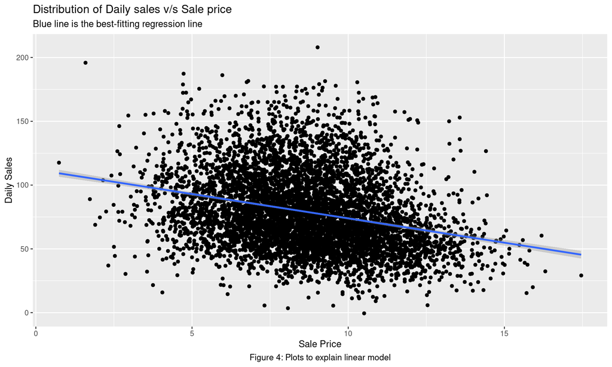

From the graph (Figure 4), it can be inferred that there is a negative correlation between the sales price and daily sales, i.e., daily sales decreases when the sales price increases.